# STECF EWG 16-19 on European data for North Atlantic and Mediterranean albacore

## ToRs

- Review completeness and quality of EU data on N-ATL and MED ALB
- Compare with what would be expected under DCF
- Review new FR mid-water trawl CE dataset and CPUE
- Information on N-ATL ALB from non-targeting fleets
- Discuss information on changes in spatial distribution
- EU sources of data on MED ALB for next SA
- Availability of information on by-catch of ALB fleets

## Review EU N-ATL & MED data

### ICCAT N-ATL T1 & T2 data catalogue

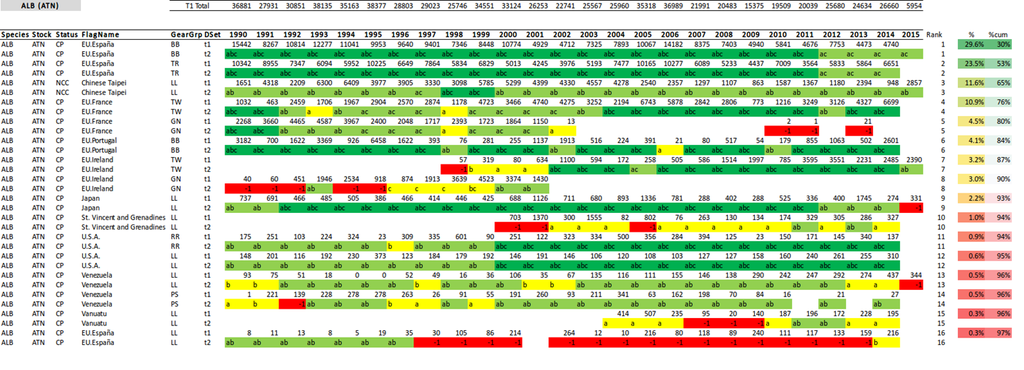

- EU data generally complete.

## Review EU N-ATL & MED data

### N-ATL EU CPUEs

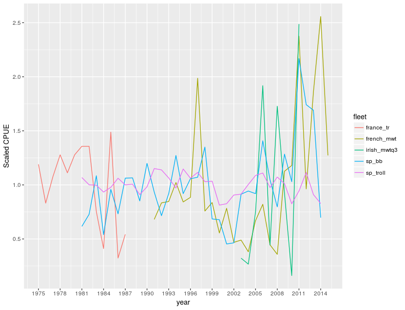

- CPUEs noisy and in some conflict
- Spatial coverage and targeting

## Review EU N-ATL & MED data

### ICCAT MED T1 & T2 data catalogue

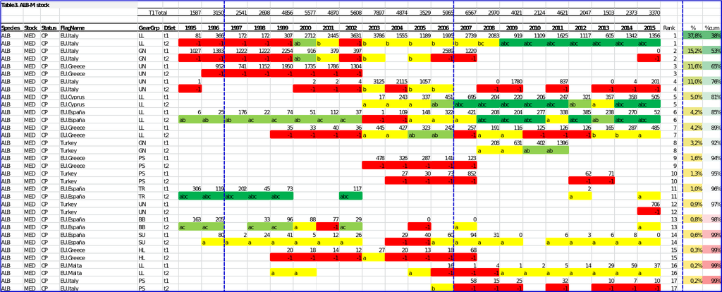

- Substantial data gaps

## Review EU N-ATL & MED data

### MED EU CPUEs

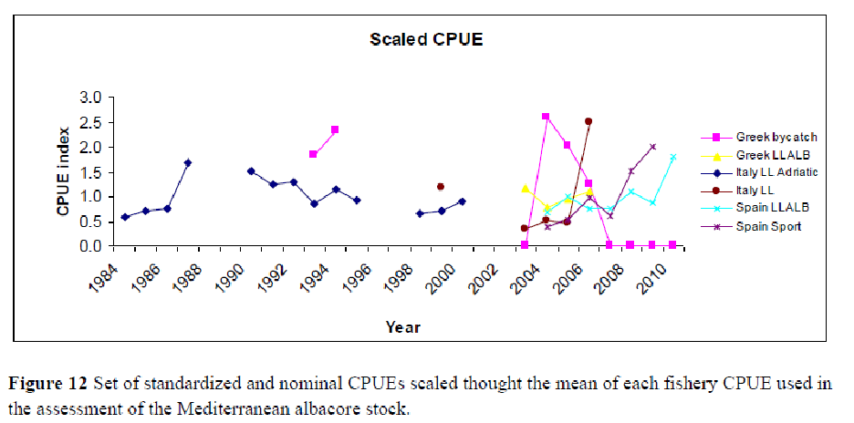

- CPUEs incomplete and insufficient

## New FR dataset mid-water trawl

### FR CPUE

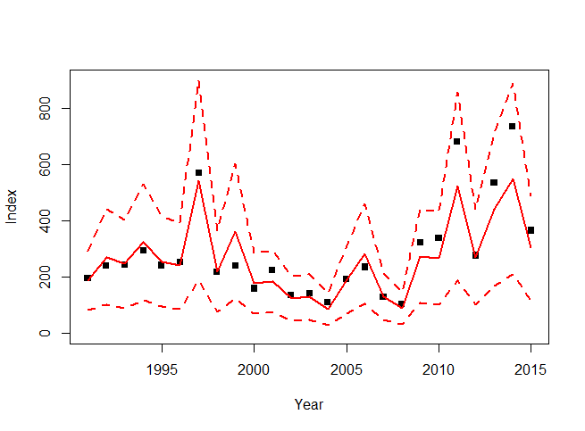

- `CPUE ~ Year + Month + Area + SST`

## N-ATL data from other fleets

### PT SWO LL CPUE

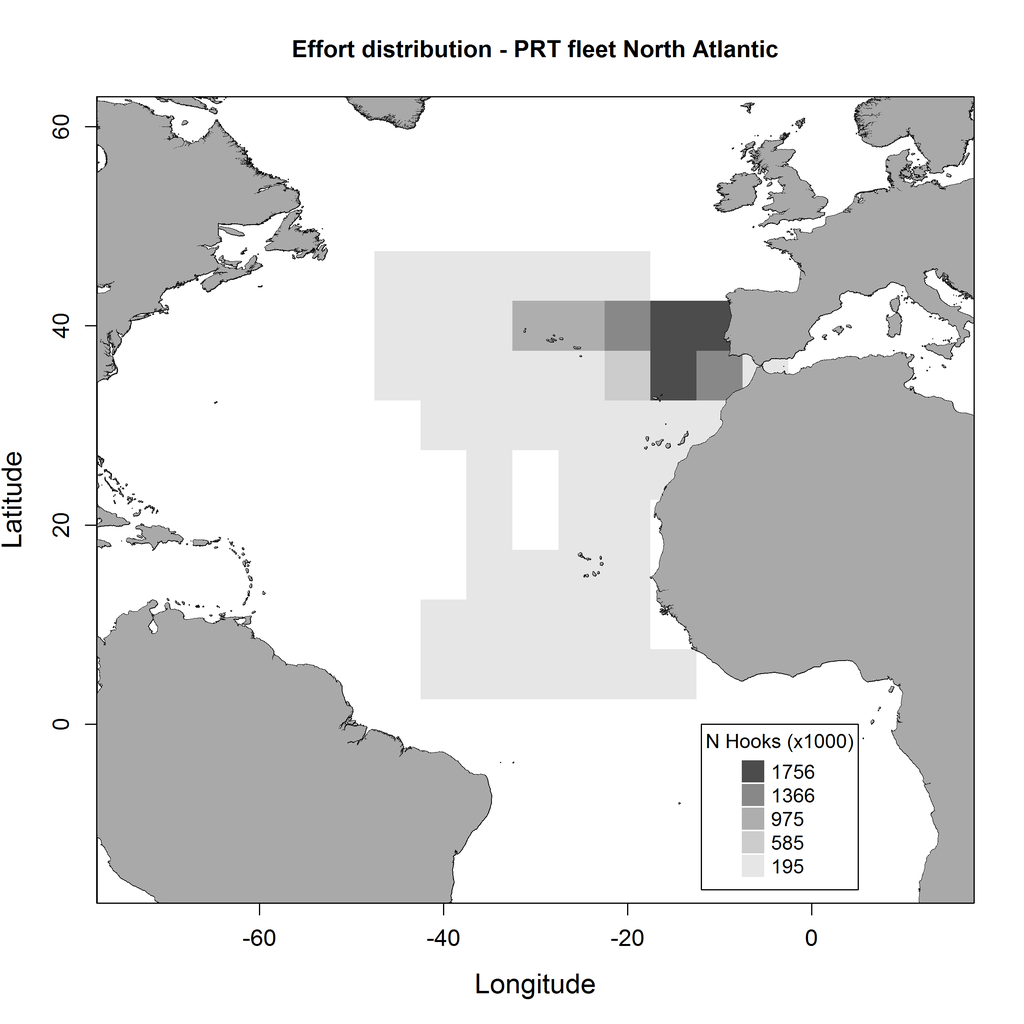

## N-ATL data from other fleets

### PT SWO LL CPUE

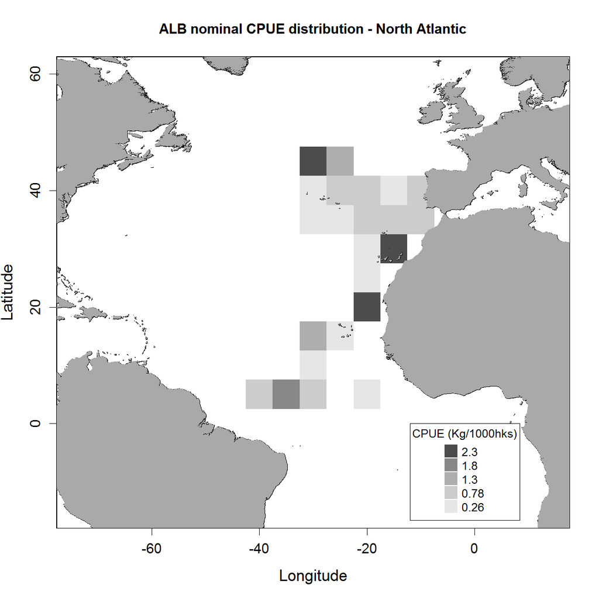

## N-ATL data from other fleets

### PT SWO LL CPUE

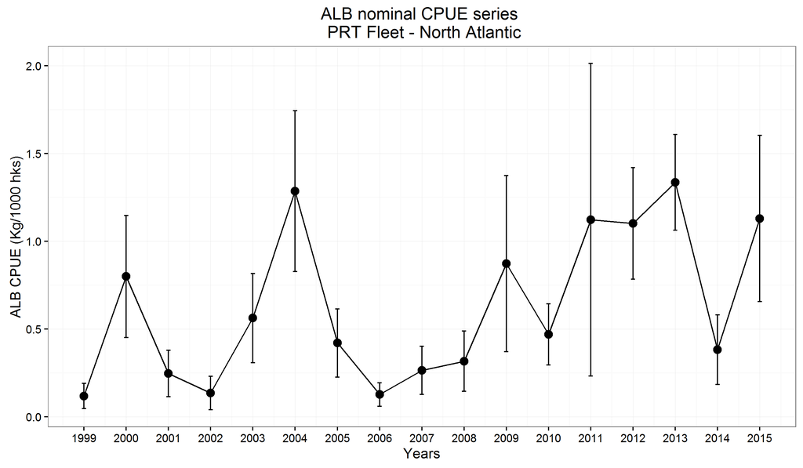

## Changes in spatial distribution of fishing

### ES TR boat numbers

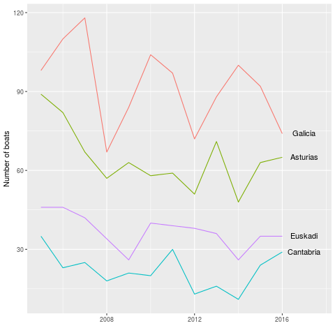

## Changes in spatial distribution of fishing

### ES TR area covered

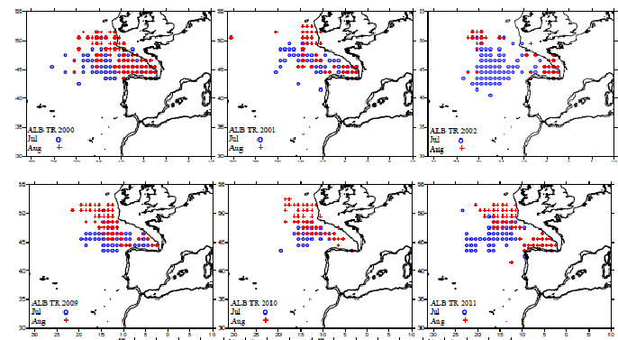

## Sources of data MED SA

### DCF

- Recover IT biological data, DATA CALL
- Analysis of all MED biological data (mat, growth, L-W)

### DCR

- Data mining exercise IT data
- Clarify IT data already at ICCAT DBs

## Data on by-catch ALB fleets N-ATL

| Fleet/gear | Available information |
| --- | --- |
| FR MWT | Obsmer dataset (France): 2006-2016 |
|  | Morizur et al (1999): 1994 |
|  | Morizur et al (1996) Study Bioeco-93-107 EC DGXIV C1: 1994 |
|  | EU Study (Ifremer-IEO): 1989-1990 |
| FR Driftnets | EU Study (Ifremer-IEO): 1989-1990 |
| IR MWT | Pilot observer program EC 812/2004: 2011 |
| ES baitboat | EU Study (Ifremer-IEO): 1989-1990 |
|  | Survey and observer (AZTI): 2009, 2011, 2016 |
| ES troll | EU Study (Ifremer-IEO): 1989-1990 |

## Data on by-catch ALB fleets MED

| Fleet/gear | Available information |
| --- | --- |
| IT ALB LL | MEDPEL project: 1995-2009 with gaps. |
|  | Italian Ministry program: 2015 |
| IT GN | Identified during MEDPEL project (Univ. Bari): 1998-2006 with gaps. |
| GR ALB LL | MEDPEL project: 2004-2006 |
| ES ALB LL | Spanish observer program (IEO): 2006-2016 (except 2014) |
| CY ALB LL | None known |

## Stay in touch

[figure not shown]

EU Science Hub: **ec.europa.eu/jrc**

[figure not shown]

Twitter: **@EU_ScienceHub**

[figure not shown]

Facebook: **EU Science Hub - Joint Research Centre**

[figure not shown]

LinkedIn: **Joint Research Centre**

[figure not shown]

YouTube: **EU Science Hub**

**Iago MOSQUEIRA**

European Commission, DG Joint Research Centre, Directorate D - Sustainable Resources, Unit D.02 Water and Marine Resources, Ispra (VA), Italy.

iago.mosqueira@ec.europa.eu